# Pemodelan ARIMA

Widianto Sijabat

1 Oktober 2026

# Pendahuluan

Laporan ini membangun model ARIMA untuk data suhu rata-rata harian (TG) Stasiun Meteorologi Kemayoran (STAID 180), Jakarta, yang bersumber dari Southeast Asian Climate Assessment & Dataset (SACA&D).

```r
library(tseries)
library(MASS)
library(forecast)
library(TSA)
library(lmtest)
```

# Persiapan Data

## Impor dan Penyesuaian Data

File `TG_STAID000180.txt` berisi 4 kolom: `SOUID`, `DATE` (YYYYMMDD), `TG` (suhu rata-rata dalam 0,1 °C), dan `Q_TG` (kode mutu; 0 = valid, 1 = suspect, 9 = missing). Nilai hilang berkode `-9999`. Sebanyak 19 baris pertama adalah keterangan sehingga dilewati.

```r
raw <- read.csv("C:\\Users\\AXIOO\\Downloads\\SACA_blended_custom\\TG_STAID000180.txt", skip = 19, strip.white = TRUE)
raw$DATE <- as.Date(as.character(raw$DATE), format = "%Y%m%d")

cat("Total baris          :", nrow(raw), "\n")
```

```
## Total baris          : 58470
```

```r
cat("Rentang tanggal      :", format(min(raw$DATE)), "s.d.", format(max(raw$DATE)), "\n")
```

```
## Rentang tanggal      : 1865-12-01 s.d. 2025-12-31
```

```r
cat("Baris dengan data    :", sum(raw$TG != -9999), "\n")
```

```
## Baris dengan data    : 48925
```

```r
cat("Baris missing (-9999):", sum(raw$TG == -9999), "\n")
```

```
## Baris missing (-9999): 9545
```

```r
d <- subset(raw, DATE >= as.Date("1997-01-01") & DATE <= as.Date("1999-12-31"))
d$suhu <- d$TG / 10          # konversi ke derajat Celsius

cat("Jumlah amatan :", nrow(d), "\n")
```

```
## Jumlah amatan : 1095
```

```r
cat("Jumlah missing:", sum(d$TG == -9999), "\n")
```

```
## Jumlah missing: 0
```

```r
cat("Jumlah data berkode suspect (Q_TG = 1):", sum(d$Q_TG == 1), "\n")
```

```
## Jumlah data berkode suspect (Q_TG = 1): 9
```

```r
summary(d$suhu)
```

```
##    Min. 1st Qu.  Median    Mean 3rd Qu.    Max.
##   23.50   27.20   28.00   27.97   28.80   31.30
```

## Eksplorasi Data Penuh

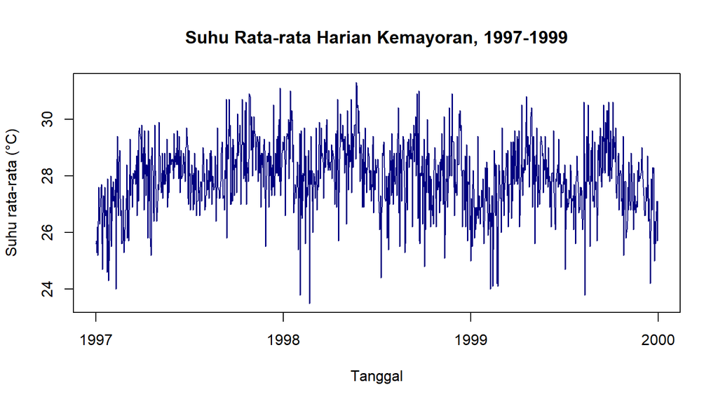

```r
suhu.ts <- ts(d$suhu, start = c(1997, 1), frequency = 365)
plot(d$DATE, d$suhu, type = "l", col = "navyblue",
     xlab = "Tanggal", ylab = "Suhu rata-rata (°C)",
     main = "Suhu Rata-rata Harian Kemayoran, 1997-1999")
```

Data bergerak di sekitar nilai tengah sekitar 28 °C tanpa tren naik atau turun yang jelas. Terdapat fluktuasi harian yang cukup besar dan beberapa hari dengan suhu rendah (hari berawan/hujan lebat).

# Langkah 1: Pembagian Data Latih dan Data Uji

Proporsi pembagian sekitar 92%:8%, dengan data uji dibuat selama 92 hari agar peramalan dapat dievaluasi untuk satu kuartal ke depan.

```r
tgl.batas <- as.Date("1999-09-30")
train <- d$suhu[d$DATE <= tgl.batas]
test  <- d$suhu[d$DATE >  tgl.batas]

c(Latih = length(train), Uji = length(test),
  Proporsi_Latih = round(length(train) / nrow(d), 3))
```

```
##          Latih            Uji Proporsi_Latih
##       1003.000         92.000          0.916
```

```r
train.ts <- ts(train)
test.ts  <- ts(test, start = length(train) + 1)
```

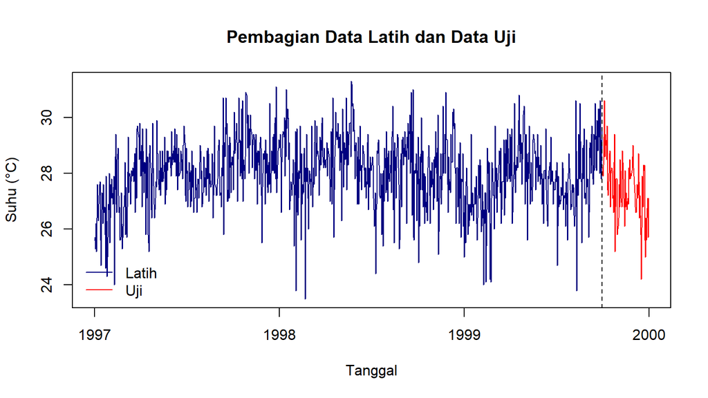

```r
plot(d$DATE, d$suhu, type = "n", xlab = "Tanggal", ylab = "Suhu (°C)",
     main = "Pembagian Data Latih dan Data Uji")
lines(d$DATE[d$DATE <= tgl.batas], train, col = "navyblue")
lines(d$DATE[d$DATE >  tgl.batas], test,  col = "red")
abline(v = tgl.batas, lty = 2)
legend("bottomleft", c("Latih", "Uji"), col = c("navyblue", "red"), lty = 1, bty = "n")
```

# Langkah 2: Uji Kestasioneran Data Latih

## Langkah 2a: Stasioneritas dalam Rataan (ACF dan ADF)

### Plot ACF

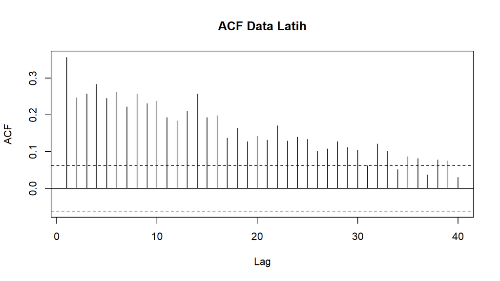

```r
acf(train.ts, lag.max = 40, main = "ACF Data Latih")
```

Plot ACF menurun perlahan (*tails off slowly*) dan nilainya tetap signifikan hingga lag-lag yang jauh. Pola ini menunjukkan data memiliki ketergantungan (memori) yang panjang, namun tidak turun secara linear seperti data yang ber-tren.

### Uji ADF

$H_0$ : Data tidak stasioner dalam rataan

$H_1$ : Data stasioner dalam rataan

```r
adf.test(train.ts)
```

```
##
##  Augmented Dickey-Fuller Test
##
## data:  train.ts
## Dickey-Fuller = -4.932, Lag order = 10, p-value = 0.01
## alternative hypothesis: stationary
```

Nilai *p-value* uji ADF sebesar 0,01 (batas terkecil yang dilaporkan) lebih kecil dari taraf nyata 5% sehingga tolak $H_0$. Data latih **stasioner dalam rataan**, sehingga tidak diperlukan *differencing*.

## Langkah 2b: Stasioneritas dalam Ragam (Box-Cox)

```r
index <- seq_along(train)
bc <- boxcox(train ~ index, lambda = seq(-1, 8, by = 0.01))
```

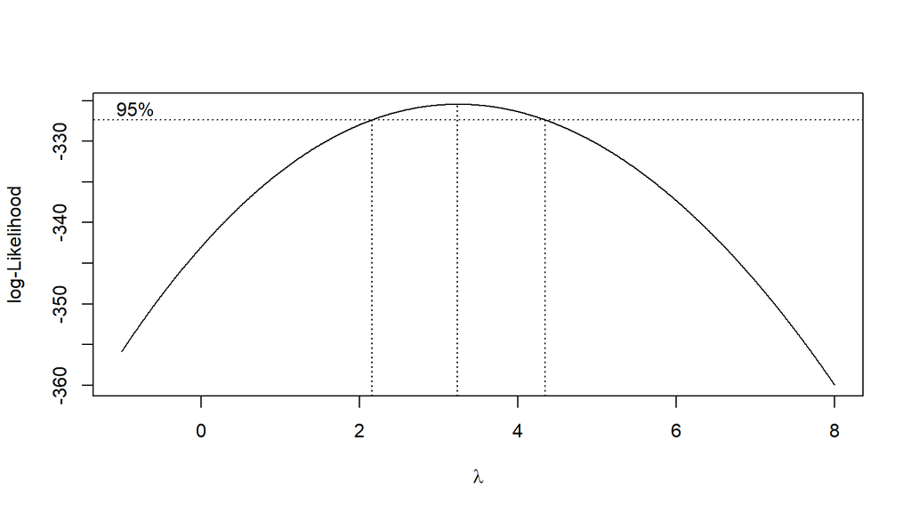

```r
lambda.opt <- bc$x[which.max(bc$y)]
ci.lambda  <- bc$x[bc$y > max(bc$y) - 0.5 * qchisq(0.95, 1)]

c(Lambda_Optimum = lambda.opt,
  Batas_Bawah = min(ci.lambda),
  Batas_Atas  = max(ci.lambda))
```

```
## Lambda_Optimum    Batas_Bawah     Batas_Atas
##           3.24           2.16           4.34
```

## Langkah 2c: Penanganan Ketidakstasioneran (Transformasi / Differencing)

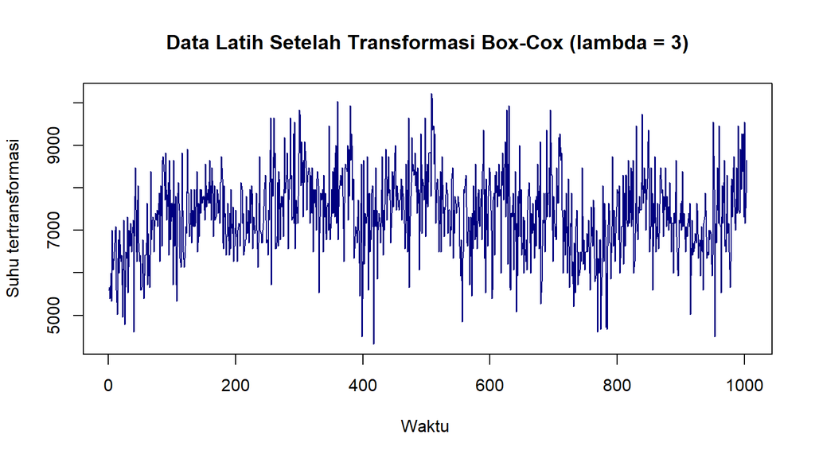

```r
lambda <- 3
train.t <- BoxCox(train, lambda)
train.t.ts <- ts(train.t)

plot.ts(train.t.ts, xlab = "Waktu ", ylab = "Suhu tertransformasi",
        col = "navyblue", main = "Data Latih Setelah Transformasi Box-Cox (lambda = 3)")
```

Pengecekan kembali kestasioneran data hasil transformasi:

```r
adf.test(train.t.ts)
```

```
##
##  Augmented Dickey-Fuller Test
##
## data:  train.t.ts
## Dickey-Fuller = -4.9519, Lag order = 10, p-value = 0.01
## alternative hypothesis: stationary
```

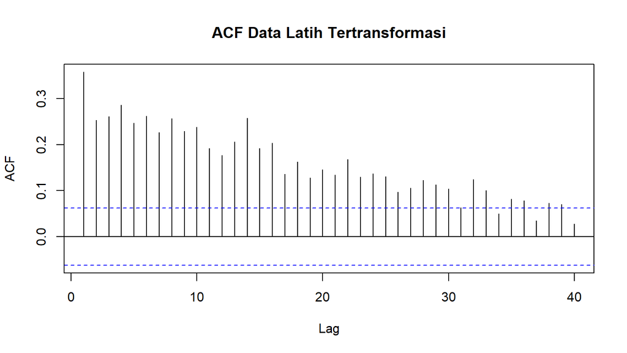

```r
acf(train.t.ts, lag.max = 40, main = "ACF Data Latih Tertransformasi")
```

Uji ADF pada data hasil transformasi menghasilkan *p-value* 0,01 sehingga data tetap stasioner dalam rataan. Pola ACF tidak berubah dari sebelumnya. Pemodelan selanjutnya menggunakan data latih hasil transformasi.

# Langkah 3: Model Potensial

## Langkah 3a: Identifikasi dengan ACF dan PACF

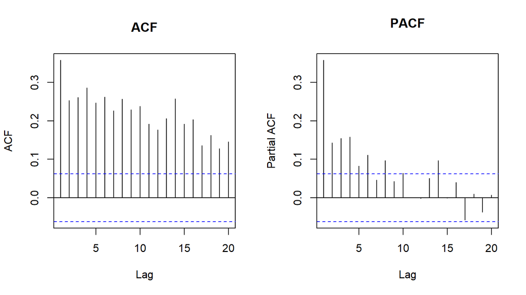

```r
par(mfrow = c(1, 2))
acf(train.t.ts,  lag.max = 20, main = "ACF")
pacf(train.t.ts, lag.max = 20, main = "PACF")
```

```r
par(mfrow = c(1, 1))
```

Plot ACF menurun perlahan (*tails off*) sedangkan plot PACF terpotong (*cuts off*) setelah beberapa lag awal (lag 1 sampai 4 yang menonjol). Hal ini mengarah pada model AR, yaitu **ARIMA(1,0,0)** dan **ARIMA(3,0,0)**.

## Langkah 3b: Identifikasi dengan EACF

```r
eacf(train.t.ts)
```

```
## AR/MA
##   0 1 2 3 4 5 6 7 8 9 10 11 12 13
## 0 x x x x x x x x x x x  x  x  x
## 1 x x o o o o o o o o o  o  o  x
## 2 x o o o o o o o o o o  o  o  x
## 3 x x x o o o o o o o o  o  o  x
## 4 x x o x o o o o o o o  o  o  x
## 5 x x x o x o o o o o o  o  o  x
## 6 x x x o x x o o o o o  o  o  x
## 7 x x x x x o o o o o o  o  o  x
```

## Langkah 3c: Pendugaan Parameter dan Uji Signifikansi

```r
m1 <- Arima(train.t.ts, order = c(1,0,0), method = "ML")
m2 <- Arima(train.t.ts, order = c(3,0,0), method = "ML")
m3 <- Arima(train.t.ts, order = c(1,0,2), method = "ML")
m4 <- Arima(train.t.ts, order = c(2,0,1), method = "ML")
m5 <- Arima(train.t.ts, order = c(2,0,2), method = "ML")
m6 <- Arima(train.t.ts, order = c(3,0,3), method = "ML")
```

```r
for (nm in c("m1","m2","m3","m4","m5","m6")) {
  m <- get(nm)
  cat("\n=====", paste0("ARIMA(", paste(arimaorder(m)[1:3], collapse = ","), ")"), "=====\n")
  print(coeftest(m))
}
```

```
##
## ===== ARIMA(1,0,0) =====
##
## z test of coefficients:
##
##             Estimate Std. Error z value  Pr(>|z|)
## ar1       3.5971e-01 2.9517e-02  12.187 < 2.2e-16 ***
## intercept 7.3673e+03 4.4034e+01 167.311 < 2.2e-16 ***
## ---
## Signif. codes:  0 '***' 0.001 '**' 0.01 '*' 0.05 '.' 0.1 ' ' 1
##
##
## ===== ARIMA(3,0,0) =====
##
## z test of coefficients:
##
##             Estimate Std. Error  z value  Pr(>|z|)
## ar1       2.8539e-01 3.1196e-02   9.1481 < 2.2e-16 ***
## ar2       9.7355e-02 3.2338e-02   3.0105  0.002608 **
## ar3       1.5745e-01 3.1268e-02   5.0356 4.763e-07 ***
## intercept 7.3670e+03 5.9828e+01 123.1365 < 2.2e-16 ***
## ---
## Signif. codes:  0 '***' 0.001 '**' 0.01 '*' 0.05 '.' 0.1 ' ' 1
##
##
## ===== ARIMA(1,0,2) =====
##
## z test of coefficients:
##
##              Estimate  Std. Error  z value  Pr(>|z|)
## ar1          0.976463    0.010173  95.9903 < 2.2e-16 ***
## ma1         -0.762723    0.033988 -22.4410 < 2.2e-16 ***
## ma2         -0.095045    0.032666  -2.9096  0.003619 **
## intercept 7363.305898  156.022908  47.1937 < 2.2e-16 ***
## ---
## Signif. codes:  0 '***' 0.001 '**' 0.01 '*' 0.05 '.' 0.1 ' ' 1
##
##
## ===== ARIMA(2,0,1) =====
##
```

[output cut: 11 more lines]

```
## ===== ARIMA(2,0,2) =====
##
## z test of coefficients:
##
##              Estimate  Std. Error  z value  Pr(>|z|)
## ar1        1.7154e-03  3.6159e-02   0.0474  0.962164
## ar2        9.3982e-01  3.5052e-02  26.8120 < 2.2e-16 ***
## ma1        1.2526e-01  4.4528e-02   2.8130  0.004908 **
## ma2       -8.0214e-01  4.0272e-02 -19.9180 < 2.2e-16 ***
## intercept  7.3512e+03  1.4435e+02  50.9265 < 2.2e-16 ***
## ---
## Signif. codes:  0 '***' 0.001 '**' 0.01 '*' 0.05 '.' 0.1 ' ' 1
##
##
## ===== ARIMA(3,0,3) =====
```

```
##
## z test of coefficients:
##
##             Estimate Std. Error z value Pr(>|z|)
## ar1          0.41423        NaN     NaN      NaN
## ar2          0.20360        NaN     NaN      NaN
## ar3          0.33495    0.20812  1.6094   0.1075
## ma1         -0.19991        NaN     NaN      NaN
## ma2         -0.20859        NaN     NaN      NaN
## ma3         -0.30918    0.13115 -2.3575   0.0184 *
## intercept 7353.04550  154.51313 47.5885   <2e-16 ***
## ---
## Signif. codes:  0 '***' 0.001 '**' 0.01 '*' 0.05 '.' 0.1 ' ' 1
```

## Langkah 3d: Perbandingan AIC dan Pemilihan Model

```r
daftar.model <- list("ARIMA(1,0,0)" = m1, "ARIMA(3,0,0)" = m2,
                     "ARIMA(1,0,2)" = m3, "ARIMA(2,0,1)" = m4,
                     "ARIMA(2,0,2)" = m5, "ARIMA(3,0,3)" = m6)

semua.signif <- function(m) {
  p <- coeftest(m)[, 4]
  p <- p[!grepl("intercept", names(p))]
  all(p < 0.05)
}

hasil.model <- data.frame(
  Model = names(daftar.model),
  AIC = sapply(daftar.model, AIC),
  BIC = sapply(daftar.model, BIC),
  Semua_Parameter_Signifikan = sapply(daftar.model, semua.signif),
  row.names = NULL
)
hasil.model[order(hasil.model$AIC), ]
```

|  | Model | AIC | BIC | Semua_Parameter_Signifikan |
| --- | --- | --- | --- | --- |
| 3 | ARIMA(1,0,2) | 16377.43 | 16401.98 | TRUE |
| 4 | ARIMA(2,0,1) | 16378.30 | 16402.86 | TRUE |
| 6 | ARIMA(3,0,3) | 16380.79 | 16420.07 | FALSE |
| 5 | ARIMA(2,0,2) | 16386.60 | 16416.06 | FALSE |
| 2 | ARIMA(3,0,0) | 16441.19 | 16465.74 | TRUE |
| 1 | ARIMA(1,0,0) | 16483.42 | 16498.15 | TRUE |

Berdasarkan pendugaan parameter, model ARIMA(1,0,2) memiliki nilai AIC dan BIC terkecil

# Langkah 4: Analisis Sisaan

Model terpilih dicek asumsi sisaannya: normalitas, kebebasan (tidak ada autokorelasi), kehomogenan ragam, dan nilai tengah sama dengan nol.

```r
model.final <- m3          # ARIMA(1,0,2)
summary(model.final)
```

```
## Series: train.t.ts
## ARIMA(1,0,2) with non-zero mean
##
## Coefficients:
##          ar1      ma1      ma2       mean
##       0.9765  -0.7627  -0.0950  7363.3059
## s.e.  0.0102   0.0340   0.0327   156.0229
##
## sigma^2 = 717748:  log likelihood = -8183.71
## AIC=16377.43   AICc=16377.49   BIC=16401.98
##
## Training set error measures:
##                    ME     RMSE      MAE       MPE     MAPE      MASE
## Training set 10.21592 845.5091 652.9166 -1.257207 9.180247 0.7797399
##                      ACF1
## Training set -0.005162531
```

```r
sisaan <- as.numeric(residuals(model.final))
```

## Langkah 4a: Eksplorasi Sisaan

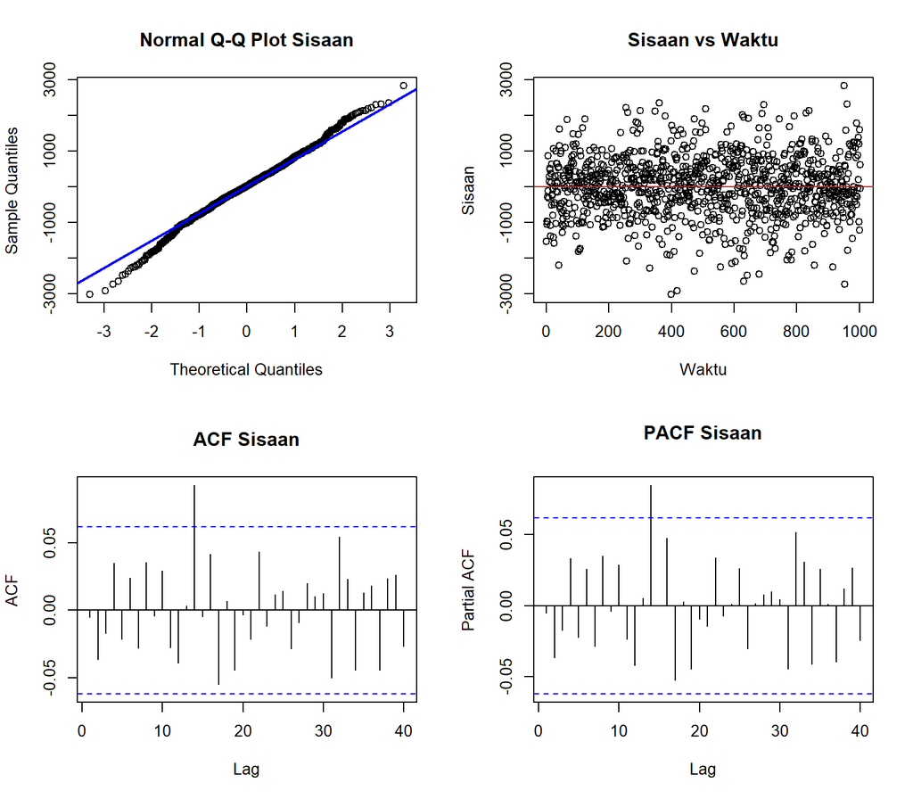

```r
par(mfrow = c(2, 2))
qqnorm(sisaan, main = "Normal Q-Q Plot Sisaan")
qqline(sisaan, col = "blue", lwd = 2)
plot(sisaan, type = "p", main = "Sisaan vs Waktu", xlab = "Waktu", ylab = "Sisaan")
abline(h = 0, col = "red")
acf(sisaan,  lag.max = 40, main = "ACF Sisaan")
pacf(sisaan, lag.max = 40, main = "PACF Sisaan")
```

```r
par(mfrow = c(1, 1))
```

## Langkah 4b: Uji Formal Sisaan

### Normalitas (Kolmogorov-Smirnov)

$H_0$ : Sisaan menyebar normal

$H_1$ : Sisaan tidak menyebar normal

```r
ks.test(sisaan, "pnorm", mean(sisaan), sd(sisaan))
```

```
##
##  Asymptotic one-sample Kolmogorov-Smirnov test
##
## data:  sisaan
## D = 0.030474, p-value = 0.3093
## alternative hypothesis: two-sided
```

### Kebebasan Sisaan (Ljung-Box)

$H_0$ : Sisaan saling bebas

$H_1$ : Sisaan tidak saling bebas

```r
Box.test(sisaan, lag = 20, type = "Ljung-Box", fitdf = 3)
```

```
##
##  Box-Ljung test
##
## data:  sisaan
## X-squared = 24.815, df = 17, p-value = 0.09893
```

### Kehomogenan Ragam (Ljung-Box pada Sisaan Kuadrat)

$H_0$ : Ragam sisaan homogen

$H_1$ : Ragam sisaan tidak homogen

```r
Box.test(sisaan^2, lag = 20, type = "Ljung-Box")
```

```
##
##  Box-Ljung test
##
## data:  sisaan^2
## X-squared = 26.682, df = 20, p-value = 0.1444
```

### Nilai Tengah Sisaan (Uji-t)

$H_0$ : Nilai tengah sisaan sama dengan 0

$H_1$ : Nilai tengah sisaan tidak sama dengan 0

```r
t.test(sisaan, mu = 0, conf.level = 0.95)
```

```
##
##  One Sample t-test
##
## data:  sisaan
## t = 0.38249, df = 1002, p-value = 0.7022
## alternative hypothesis: true mean is not equal to 0
## 95 percent confidence interval:
##  -42.19548  62.62732
## sample estimates:
## mean of x
##  10.21592
```

| Asumsi | Uji | *p-value* | Keputusan |
| --- | --- | --- | --- |
| Normalitas | Kolmogorov-Smirnov | 0,3093 | Gagal tolak $H_0$, sisaan menyebar normal |
| Kebebasan | Ljung-Box | 0,0989 | Gagal tolak $H_0$, sisaan saling bebas |
| Homogenitas ragam | Ljung-Box (sisaan kuadrat) | 0,1444 | Gagal tolak $H_0$, ragam sisaan homogen |
| Nilai tengah nol | Uji-t | 0,7022 | Gagal tolak $H_0$, nilai tengah sisaan sama dengan 0 |

# Langkah 5: Overfitting

*Overfitting* dilakukan dengan menaikkan orde AR dan MA model terpilih ARIMA(1,0,2) satu tingkat, yaitu ARIMA(2,0,2) dan ARIMA(1,0,3).

```r
m3a <- Arima(train.t.ts, order = c(2,0,2), method = "ML")
m3b <- Arima(train.t.ts, order = c(1,0,3), method = "ML")

cat("===== ARIMA(2,0,2) =====\n"); print(coeftest(m3a))
```

```
## ===== ARIMA(2,0,2) =====
```

```
##
## z test of coefficients:
##
##              Estimate  Std. Error  z value  Pr(>|z|)
## ar1        1.7154e-03  3.6159e-02   0.0474  0.962164
## ar2        9.3982e-01  3.5052e-02  26.8120 < 2.2e-16 ***
## ma1        1.2526e-01  4.4528e-02   2.8130  0.004908 **
## ma2       -8.0214e-01  4.0272e-02 -19.9180 < 2.2e-16 ***
## intercept  7.3512e+03  1.4435e+02  50.9265 < 2.2e-16 ***
## ---
## Signif. codes:  0 '***' 0.001 '**' 0.01 '*' 0.05 '.' 0.1 ' ' 1
```

```r
cat("\n===== ARIMA(1,0,3) =====\n"); print(coeftest(m3b))
```

```
##
## ===== ARIMA(1,0,3) =====
```

```
##
## z test of coefficients:
##
##              Estimate  Std. Error  z value  Pr(>|z|)
## ar1          0.974336    0.010947  89.0019 < 2.2e-16 ***
## ma1         -0.766875    0.033402 -22.9591 < 2.2e-16 ***
## ma2         -0.118644    0.037700  -3.1470  0.001649 **
## ma3          0.035974    0.031139   1.1553  0.247982
## intercept 7363.113226  151.651612  48.5528 < 2.2e-16 ***
## ---
## Signif. codes:  0 '***' 0.001 '**' 0.01 '*' 0.05 '.' 0.1 ' ' 1
```

```r
data.frame(
  Model = c("ARIMA(1,0,2)", "ARIMA(2,0,2)", "ARIMA(1,0,3)"),
  AIC = c(AIC(m3), AIC(m3a), AIC(m3b)),
  BIC = c(BIC(m3), BIC(m3a), BIC(m3b)),
  Semua_Parameter_Signifikan = c(semua.signif(m3), semua.signif(m3a), semua.signif(m3b))
)
```

| Model | AIC | BIC | Semua_Parameter_Signifikan |
| --- | --- | --- | --- |
| ARIMA(1,0,2) | 16377.43 | 16401.98 | TRUE |
| ARIMA(2,0,2) | 16386.60 | 16416.06 | FALSE |
| ARIMA(1,0,3) | 16378.09 | 16407.56 | FALSE |

Model hasil *overfitting* tidak lebih baik daripada ARIMA(1,0,2). ARIMA(2,0,2) memiliki AIC (16386,60) dan BIC yang lebih besar serta parameter `ar1` tidak signifikan. ARIMA(1,0,3) memiliki AIC (16378,09) dan BIC yang juga lebih besar dan parameter `ma3` tidak signifikan (*p-value* 0,248). Dengan demikian model **ARIMA(1,0,2)** tetap dipilih untuk peramalan.

# Langkah 6: Peramalan (Forecast)

Peramalan dilakukan sepanjang data uji (92 hari).

```r
h <- length(test)
ramalan <- forecast(model.final, h = h, level = 95)

ramalan.asli <- InvBoxCox(as.numeric(ramalan$mean),  lambda)
bawah.asli   <- InvBoxCox(as.numeric(ramalan$lower), lambda)
atas.asli    <- InvBoxCox(as.numeric(ramalan$upper), lambda)

head(data.frame(Hari = 1:h, Aktual = test, Ramalan = round(ramalan.asli, 2),
                Bawah95 = round(bawah.asli, 2), Atas95 = round(atas.asli, 2)), 10)
```

|  | Hari | Aktual | Ramalan | Bawah95 | Atas95 |
| --- | --- | --- | --- | --- | --- |
| 1 | 1 | 28.2 | 29.02 | 26.90 | 30.87 |
| 2 | 2 | 27.9 | 28.93 | 26.74 | 30.83 |
| 3 | 3 | 28.3 | 28.91 | 26.70 | 30.82 |
| 4 | 4 | 29.3 | 28.89 | 26.66 | 30.82 |
| 5 | 5 | 30.6 | 28.87 | 26.63 | 30.81 |
| 6 | 6 | 28.6 | 28.85 | 26.59 | 30.80 |
| 7 | 7 | 29.4 | 28.83 | 26.56 | 30.80 |
| 8 | 8 | 29.0 | 28.82 | 26.53 | 30.79 |
| 9 | 9 | 28.5 | 28.80 | 26.50 | 30.78 |
| 10 | 10 | 29.7 | 28.78 | 26.47 | 30.78 |

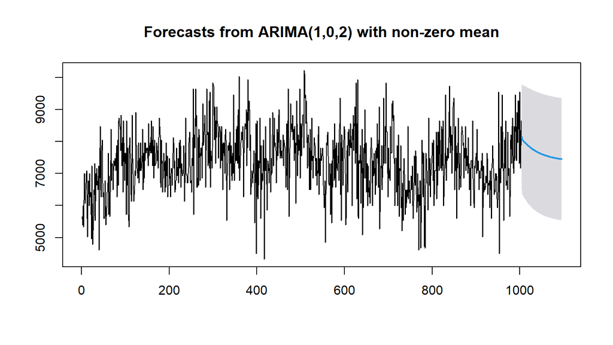

```r
data.ramalan <- ramalan$mean
plot(ramalan)
```

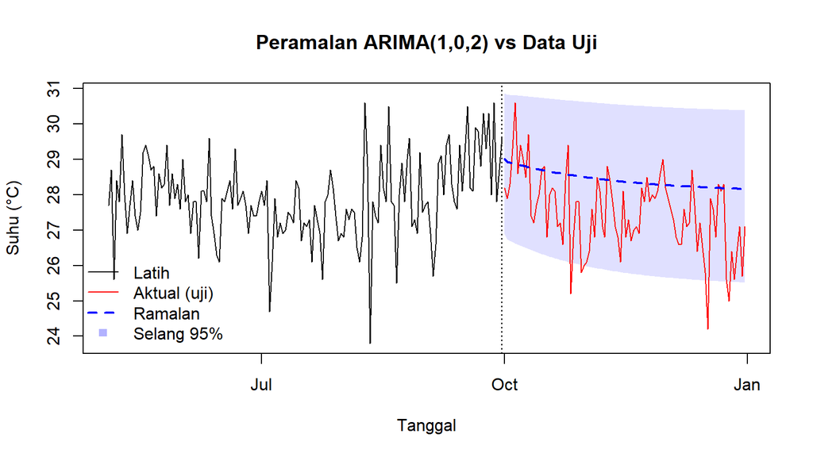

```r
tgl.latih <- d$DATE[d$DATE <= tgl.batas]
tgl.uji   <- d$DATE[d$DATE >  tgl.batas]
tampil    <- tail(seq_along(train), 150)      # 150 hari terakhir data latih

plot(c(tgl.latih[tampil], tgl.uji),
     c(train[tampil], test), type = "n",
     ylim = range(c(train[tampil], test, bawah.asli, atas.asli)),
     xlab = "Tanggal", ylab = "Suhu (°C)",
     main = "Peramalan ARIMA(1,0,2) vs Data Uji")
polygon(c(tgl.uji, rev(tgl.uji)), c(bawah.asli, rev(atas.asli)),
        col = rgb(0, 0, 1, 0.12), border = NA)
lines(tgl.latih[tampil], train[tampil], col = "black")
lines(tgl.uji, test, col = "red")
lines(tgl.uji, ramalan.asli, col = "blue", lwd = 2, lty = 2)
abline(v = tgl.batas, lty = 3)
legend("bottomleft", c("Latih", "Aktual (uji)", "Ramalan", "Selang 95%"),
       col = c("black", "red", "blue", rgb(0,0,1,0.3)),
       lty = c(1, 1, 2, NA), lwd = c(1, 1, 2, NA), pch = c(NA, NA, NA, 15), bty = "n")
```

## Langkah 6a: Akurasi Peramalan

```r
akurasi <- accuracy(ramalan.asli, test)
akurasi
```

```
##                  ME     RMSE      MAE       MPE   MAPE
## Test set -0.9521717 1.390989 1.106472 -3.616881 4.1405
```

```r
cakupan <- mean(test >= bawah.asli & test <= atas.asli)
```